# HW 7

# Question 8

What is the percentage of positive words in the news headlines? What is the percentage of negative words? Make a barplot for each (for positive and negative words that showed up separately) showing the most frequent words for words that showed up at least 20 times. (Note: don’t forget to get the total number of unique words that showed up in the data.)

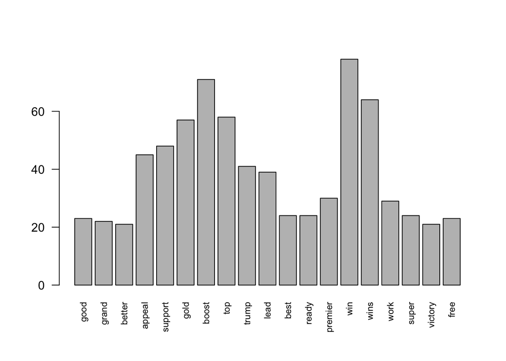

```r
totalWords <- sum(wordCounts)
matched_p <- match(names(wordCounts), posWords, nomatch=0)
matched_n <- match(names(wordCounts), negWords, nomatch=0)

matched_p <- matched_p != 0
matched_n <- matched_n != 0

matched_p <- wordCounts[matched_p]
matched_n <- wordCounts[matched_n]

barplot(matched_p[matched_p >20], las=2, cex.names=.75)
```

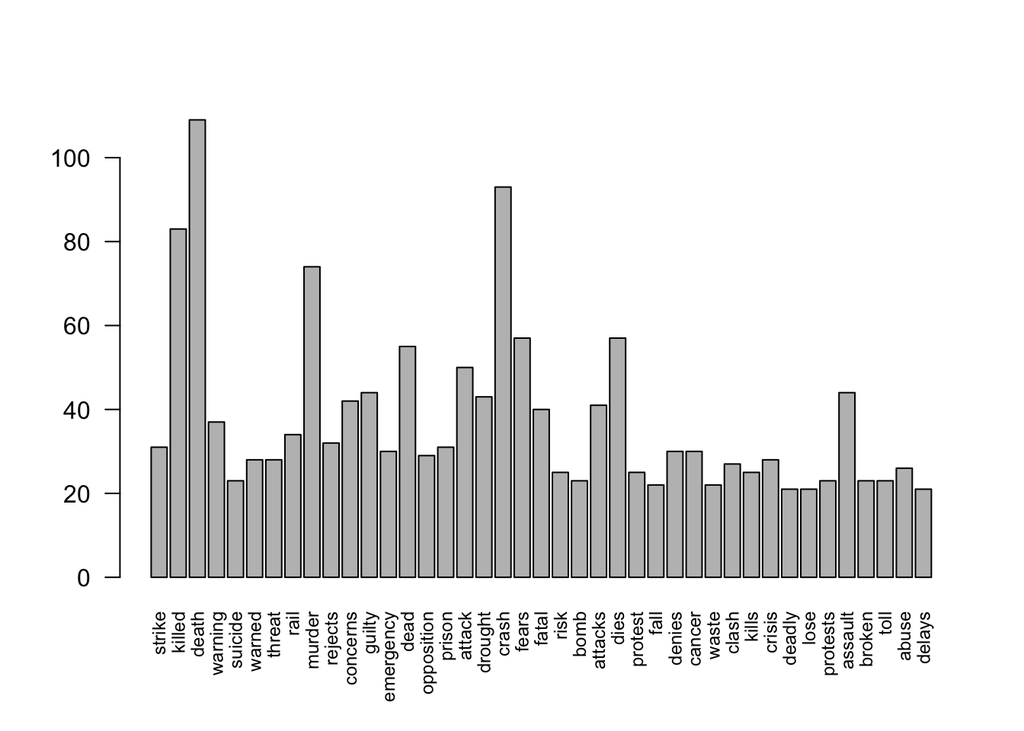

```r
barplot(matched_n[matched_n >20], las=2, cex.names=.75)
```

```r
sum(matched_p)/totalWords
```

```
## [1] 0.03734345
```

```r
sum(matched_n)/totalWords
```

```
## [1] 0.07770398
```

Let’s get the number of articles published in each year and month. Note that the chunk below creates two new variables `count` and `yearmonth`:

```r
news <- news %>% group_by(year,month) %>% mutate(count=n(), yearmonth = paste(year, month,sep = '/')) %>% arrange(year,month,day)
```

# Question 9

Using `ggplot2`, create a barplot for the frequency of articles released in each year and month. On the x axis, you should have year month, e.g., 2003/10, 2003/11, 2003/12, 2004/1, on the y-axis you should have the number of articles released in the data. Do you see a change in the number of articles released across years? (Hint: use `factor()` with `levels=` options specified when you call `aes(x=)` to have a proper chronological sorting on your x axis. Use `+theme(axis.text=element_text(size=4,angle=90)` to fit the dates on the x axis.)

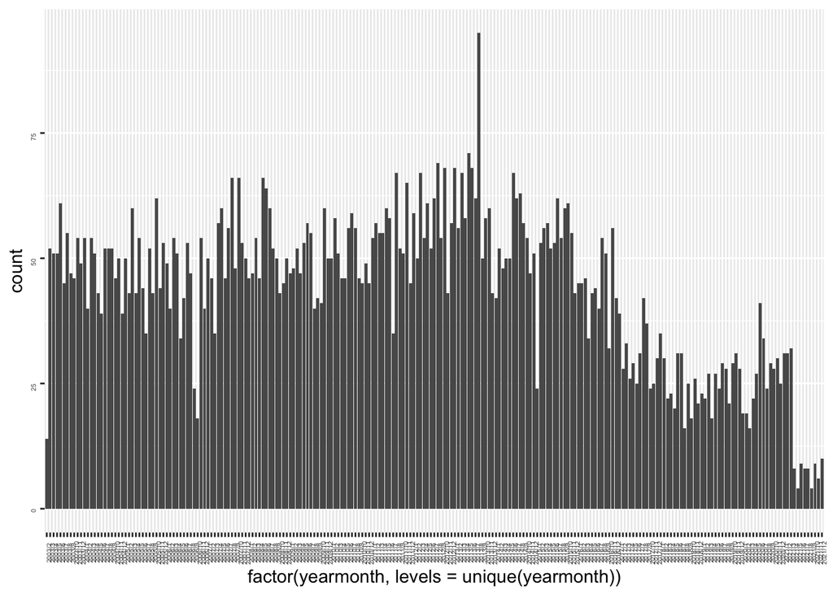

```r
ggplot(news, aes(x=factor(yearmonth, levels=unique(yearmonth)))) + geom_bar() + theme(axis.text=element_text(size=4,angle=90))
```

Let’s now practice working with `quanteda` and `corpus` packages. Install the packages first if you don’t have them in your computer and load them in in R.

```r
library("quanteda")
#library('corpus')
```

# Question 10

Using the `term_stats()` function, return the 20 most frequent single words that show up in the data. Make sure to filter out * punctuation * symbols * stopwords

```r
head(termFreq(charVector, control = list(removePunctuation=TRUE, stopwords=FALSE)), 20)
```

```
##   0307   0312   0401   0402   0607   0609    100   1000  10000 100000 1000th
##      1      1      1      1      1      1     14      3      3      1      1
##   100k 100kph   100m   1013    105    107   1080    10m   10pc
##      2      1      2      1      1      1      1      2      1
```

# Question 11

```r
head(termFreq(charVector, control = list(removePunctuation=TRUE, stopwords=FALSE)), 20)
```

```
##   0307   0312   0401   0402   0607   0609    100   1000  10000 100000 1000th
##      1      1      1      1      1      1     14      3      3      1      1
##   100k 100kph   100m   1013    105    107   1080    10m   10pc
##      2      1      2      1      1      1      1      2      1
```

# Question 12

Create a corpus object using `corpus()` function. Store it in an object named `newscorpus`. Convert `newscorpus` into paragraphs with `corpus_reshape()`.

```r
newscorpus <- corpus(charVector)
newscorpus <- corpus_reshape(newscorpus, to="paragraphs")
newscorpus
```

```
## Corpus consisting of 10,000 documents.
## text1 :
## "people flock to kabul airport as taliban seizes capital"
##
## text2 :
## "senior liberals desert turnbull"
##
## text3 :
## "interview matt scott"
##
## text4 :
## "one plus one: jim cassidy"
##
## text5 :
## "more australians leave lebanon"
##
## text6 :
## "melb housing plan released"
##
## [ reached max_ndoc ... 9,994 more documents ]
```

# Question 13

Create a term document matrix named `news_dtm` by using the `dfm()` function. While you call `dfm()`, make sure to clean the paragraphs by keeping only the stems of the words, removing punctuations, removing symbols, removing numbers, and removing stopwords. If you wish to get rid of anything that does not look correct in the data (such as weird bunch of characters that show up as “words”) you may trim them out at this stage using `dfm_remove()`. Finally, trim `news_dtm` such that it contains only words that show up at least 50 times. Print the first 6 rows of `news_dtm`. (Note: Again, ignore warnings.)

```r
news_dtm <- dfm(newscorpus, stem=TRUE, remove_punct=TRUE, remove_symbols = TRUE, remove_numbers = TRUE, remove=c(stopwords("english")))
news_dtm <- dfm_trim(news_dtm, min_termfreq=50)
head(news_dtm)
```

```
## Document-feature matrix of: 6 documents, 172 features (99.42% sparse) and 0 docvars.
##        features
## docs    interview one australian hous plan releas south west open polic
##   text1         0   0          0    0    0      0     0    0    0     0
##   text2         0   0          0    0    0      0     0    0    0     0
##   text3         1   0          0    0    0      0     0    0    0     0
##   text4         0   2          0    0    0      0     0    0    0     0
##   text5         0   0          1    0    0      0     0    0    0     0
##   text6         0   0          0    1    1      1     0    0    0     0
## [ reached max_nfeat ... 162 more features ]
```

# Question 14

Create a wordcloud of `news_dtm` using `textplot_wordcloud()`. Comment on words that you were surprised and not surprised to see in the news headlines dataset.

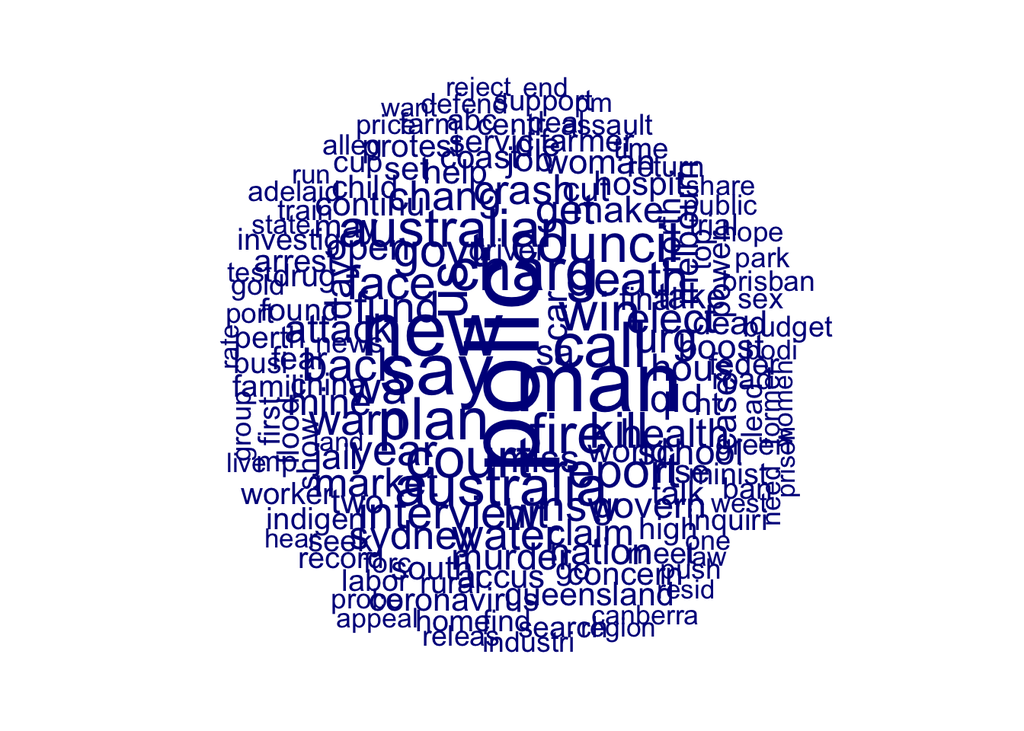

```r
library("quanteda.textplots")
textplot_wordcloud(news_dtm,adjust=0.5)
```

```r
#I am NOT surprised to see "police", "news", "court", "health", "interview", "gov", and "public", because these are normal words I would expect to see in a news article.
#I am surprised to see "man", because I didn't expect it to be such a difference between news about men and women, "fire" because I wouldn't expect fires to be THAT common to be one of the top words, "warn", and "price", I feel are less common words.
```

Let’s now do topic modeling. Make sure to load necessary packages via

```r
library("topicmodels")
library('tidytext')
```